# Nanopore bulk RNA-Seq and scRNA-Seq data benchmarks (top 500 highly variable transcripts)

# Preparing the data

Load the required packages:

```r
library(tidyverse)
library(glue)
library(scales)
library(Matrix)
library(scater)
library(scran)
library(pheatmap)
library(viridis)
```

Global parameters:

```r
csv_dir <- "nanopore_bulk_sc_benchmarks_hvts_data"
dir.create(csv_dir, recursive = TRUE)
bulk_dir <- file.path("..", "nanopore_bulk_analysis", "report_data")
sc_dir <- file.path("..", "nanopore_sc_analysis", "report_data")
souporcell_file <- file.path("..", "illumina_sc_analysis", "data",
                             "souporcell_clusters.tsv")
bulk_sample_ids <- c("LIB5432309_SAM24385452", "LIB5432310_SAM24385453",
                     "LIB5432311_SAM24385454", "LIB5432312_SAM24385455",
                     "LIB5432313_SAM24385456", "LIB5432314_SAM24385457",
                     "LIB5432315_SAM24385458", "LIB5432316_SAM24385459")
bulk_sample_names <- c("OVMANA", "OVKATE", "OVTOKO", "SK-OV-3", "COV362",
                       "COV504", "IGROV-1")
bulk_sample_order <- c("SK-OV-3", "IGROV-1", "COV504", "OVMANA", "OVKATE",
                       "OVTOKO", "COV362")
cell_min_txs <- 500
top_n_hvts <- 500
min_cor_spearman <- 0.3
max_cor_spearman <- 0.9
min_mean_rel_diff <- 0.5
max_mean_rel_diff <- 1.1
heatmap_palette <- cividis
heatmap_palette_direction <- 1
scatterplot_df_list <- list()
```

Helper functions:

```r
fill_missing_matrix <- function(x, all_rownames) {
    missing_rownames <- setdiff(all_rownames, rownames(x))
    missing_matrix <- matrix(
        0, nrow = length(missing_rownames), ncol = ncol(x)
    )
    rownames(missing_matrix) <- missing_rownames
    full_matrix <- rbind(x, missing_matrix)
    full_matrix <- full_matrix[all_rownames,]
    return(full_matrix)
}
get_hvts <- function(count_matrix) {
    sce <- SingleCellExperiment(assays = list(counts = count_matrix))
    sce <- sce[, colSums(count_matrix > 0) >= cell_min_txs]
    sce <- computeLibraryFactors(sce)
    sce <- logNormCounts(sce)
    dec <- modelGeneVar(sce)
    top_hvts <- getTopHVGs(dec, n = top_n_hvts)
    return(top_hvts)
}
get_mean_rel_diff <- function(x, y) {
    selector <- (x != 0) & (y != 0)
    x <- x[selector]
    y <- y[selector]
    mean(abs(x - y) / ((x + y) / 2))
}
get_mean_rel_diff_matrix <- function(x, y) {
    apply(y, 2, function(y_values) {
        apply(x, 2, function(x_values) {
            selector <- (y_values != 0) & (x_values != 0)
            y_values <- y_values[selector]
            x_values <- x_values[selector]
            mean(abs(x_values - y_values) / ((x_values + y_values) / 2))
        })
    })
}
prepare_scatterplot_data <- function(tpm_matrix_bulk,
                                     tpm_matrix_pseudobulk) {
    tpm_bulk_df <- as.data.frame(tpm_matrix_bulk[, 1:3])
    bulk_levels <- colnames(tpm_bulk_df)
    tpm_bulk_df$transcript_id <- rownames(tpm_bulk_df)
    rownames(tpm_bulk_df) <- NULL
    tpm_bulk_df <- tpm_bulk_df %>%
        gather(-transcript_id, key = "sample_bulk", value = "tpm_bulk")
    tpm_bulk_df$sample_bulk <- factor(
        tpm_bulk_df$sample_bulk, levels = bulk_levels
    )
    tpm_pseudobulk_df <- as.data.frame(tpm_matrix_pseudobulk)
    pseudobulk_levels <- colnames(tpm_pseudobulk_df)
    tpm_pseudobulk_df$transcript_id <- rownames(tpm_pseudobulk_df)
    rownames(tpm_pseudobulk_df) <- NULL
    tpm_pseudobulk_df <- tpm_pseudobulk_df %>%
        gather(-transcript_id, key = "sample_pseudobulk",
               value = "tpm_pseudobulk")
    tpm_pseudobulk_df$sample_pseudobulk <- factor(
        tpm_pseudobulk_df$sample_pseudobulk, levels = pseudobulk_levels
    )
    tpm_df <- left_join(tpm_bulk_df, tpm_pseudobulk_df)
    tpm_df$status <- ifelse(
        as.numeric(tpm_df$sample_bulk) ==
            as.numeric(tpm_df$sample_pseudobulk),
        "Correct vs Correct", "Correct vs Decoy"
    )
    tpm_df$status <- factor(
        tpm_df$status,
        levels = c("Correct vs Correct", "Correct vs Decoy")
    )
    return(tpm_df)
}
create_scatterplot_paired <- function(plot_df) {
    plot_df$tpm_bulk[plot_df$tpm_bulk < 0.1] <- 0.1
    plot_df$tpm_pseudobulk[plot_df$tpm_pseudobulk < 0.1] <- 0.1
    scatter_plot <- ggplot(plot_df, mapping = aes(x = tpm_bulk,
                                                  y = tpm_pseudobulk)) +
        geom_point(alpha = 0.35, size = 0.05) +
        geom_abline(intercept = 0, slope = 1,
                    lty = 3, color = "red") +
        facet_grid(rows = vars(sample_pseudobulk),
                   cols = vars(sample_bulk)) +
        scale_x_log10(labels = trans_format("log10", math_format(10^.x))) +
        scale_y_log10(labels = trans_format("log10", math_format(10^.x))) +
        coord_cartesian(xlim = c(0.1, 10^5),
                        ylim = c(0.1, 10^5),
                        clip = "off") +
        annotation_logticks(outside = TRUE,
                            size = 0.25,
                            short = unit(0.05, "cm"),
                            mid = unit(0.1, "cm"),
                            long = unit(0.15, "cm")) +
        theme_bw() +
        theme(aspect.ratio = 1,
              axis.title.x = element_blank(),
              axis.title.y = element_blank())
    return(scatter_plot)
}
create_scatterplot_combined <- function(plot_df) {
    plot_df$tpm_bulk[plot_df$tpm_bulk < 0.1] <- 0.1
    plot_df$tpm_pseudobulk[plot_df$tpm_pseudobulk < 0.1] <- 0.1
    scatter_plot <- ggplot(plot_df, mapping = aes(x = tpm_bulk,
                                                  y = tpm_pseudobulk)) +
        geom_point(alpha = 0.35, size = 0.05) +
        geom_abline(intercept = 0, slope = 1,
                    lty = 3, color = "red") +
        facet_grid(cols = vars(status)) +
        scale_x_log10(labels = trans_format("log10", math_format(10^.x))) +
        scale_y_log10(labels = trans_format("log10", math_format(10^.x))) +
        coord_cartesian(xlim = c(0.1, 10^5),
                        ylim = c(0.1, 10^5),
                        clip = "off") +
        annotation_logticks(outside = TRUE,
                            size = 0.25,
                            short = unit(0.05, "cm"),
                            mid = unit(0.1, "cm"),
                            long = unit(0.15, "cm")) +
        theme_bw() +
        theme(aspect.ratio = 1,
              axis.title.x = element_blank(),
              axis.title.y = element_blank())
    return(scatter_plot)
}
```

Prepare mitochondrial transcript blacklist:

```r
se_transcript_mt <- readRDS(file.path(
    sc_dir, "isosceles_se_transcript.rds"
))
se_transcript_mt <- se_transcript_mt[
    grepl("^MT:", rowData(se_transcript_mt)$position),
]
mt_transcripts_isosceles <- rownames(se_transcript_mt)
mt_transcripts_ensembl <- rowData(se_transcript_mt)$compatible_tx
mt_transcripts_isosceles <- c(
    mt_transcripts_isosceles,
    c("ISOT-0000-0000-0000-2622:s10197250:e10199150:FA:FL",
      "ISOT-0000-0000-0000-caeb:s10507850:e10509200:FA:FL",
      "ISOT-0000-0000-0000-2809:s96617150:e96618250:FA:FL")
)
mt_transcripts_ensembl <- c(
    mt_transcripts_ensembl,
    c("ENST00000445125", "ENST00000536684", "ENST00000600213")
)
```

Prepare Souporcell cluster data:

```r
souporcell_df <- read.delim(souporcell_file)
souporcell_barcode <- gsub("-1$", "", souporcell_df$barcode)
souporcell_cluster <- ifelse(souporcell_df$status == "singlet",
                             souporcell_df$assignment,
                             souporcell_df$status)
souporcell_cluster <- setNames(souporcell_cluster, souporcell_barcode)
```

# Isosceles bulk-pseudobulk correlation plots

Prepare Isosceles scRNA-Seq data:

```r
se <- readRDS(file.path(
    sc_dir, "isosceles_se_transcript.rds"
))
colnames(se) <- sapply(strsplit(colnames(se), "\\."), "[", 2)
sc_counts <- assay(se, "counts")
sc_counts <- sc_counts[
    !(rownames(sc_counts) %in% mt_transcripts_isosceles),
]
cell_labels <- souporcell_cluster[colnames(sc_counts)]
cell_selector <- cell_labels %in% c("0", "1", "2")
sc_counts <- sc_counts[, cell_selector]
```

Prepare Isosceles pseudobulk RNA-Seq data:

```r
se_pseudobulk <- readRDS(file.path(
    sc_dir, "isosceles_se_pseudobulk_transcript.rds"
))
se_pseudobulk <- se_pseudobulk[, 1:3]
colnames(se_pseudobulk) <- paste0("C", colnames(se_pseudobulk))
tpm_pseudobulk <- assay(se_pseudobulk, "tpm")
tpm_pseudobulk <- tpm_pseudobulk[
    !(rownames(tpm_pseudobulk) %in% mt_transcripts_isosceles),
]
tpm_pseudobulk <- t(
    t(tpm_pseudobulk) / colSums(tpm_pseudobulk) * 1e6
)
```

Prepare Isosceles bulk RNA-Seq data:

```r
se_bulk <- readRDS(file.path(
    bulk_dir, "isosceles_se_transcript.rds"
))
tpm_bulk <- assay(se_bulk, "tpm")
tpm_bulk[, 7] <- (tpm_bulk[, 7] + tpm_bulk[, 8]) / 2
tpm_bulk <- tpm_bulk[, 1:7]
colnames(tpm_bulk) <- bulk_sample_names
tpm_bulk <- tpm_bulk[, bulk_sample_order]
tpm_bulk <- tpm_bulk[
    !(rownames(tpm_bulk) %in% mt_transcripts_isosceles),
]
tpm_bulk <- t(
    t(tpm_bulk) / colSums(tpm_bulk) * 1e6
)
```

Select top transcripts for further analysis:

```r
top_transcripts <- get_hvts(sc_counts)
```

Re-normalize the TPM values:

```r
tpm_bulk <- tpm_bulk[top_transcripts,]
tpm_pseudobulk <- tpm_pseudobulk[top_transcripts,]
tpm_bulk <- t(
    t(tpm_bulk) / colSums(tpm_bulk) * 1e6
)
tpm_pseudobulk <- t(
    t(tpm_pseudobulk) / colSums(tpm_pseudobulk) * 1e6
)
```

Calculate the correlation matrices:

```r
cor_spearman <- cor(tpm_pseudobulk[top_transcripts,],
                    tpm_bulk[top_transcripts,],
                    method = "spearman")
mean_rel_diff <- get_mean_rel_diff_matrix(
    tpm_pseudobulk[top_transcripts,],
    tpm_bulk[top_transcripts,]
)
```

Spearman correlation matrix:

```r
as.data.frame(cor_spearman)
```

|  | SK-OV-3 | IGROV-1 | COV504 | OVMANA | OVKATE | OVTOKO | COV362 |
| --- | --- | --- | --- | --- | --- | --- | --- |
| C0 | 0.8829653 | 0.4777647 | 0.4635775 | 0.5117028 | 0.4849133 | 0.6371585 | 0.5455585 |
| C1 | 0.4106299 | 0.8460751 | 0.3567887 | 0.6419524 | 0.4920299 | 0.6030005 | 0.5582198 |
| C2 | 0.4532513 | 0.3946001 | 0.8638338 | 0.5027699 | 0.6492066 | 0.5100029 | 0.7007899 |

Spearman correlation heatmap:

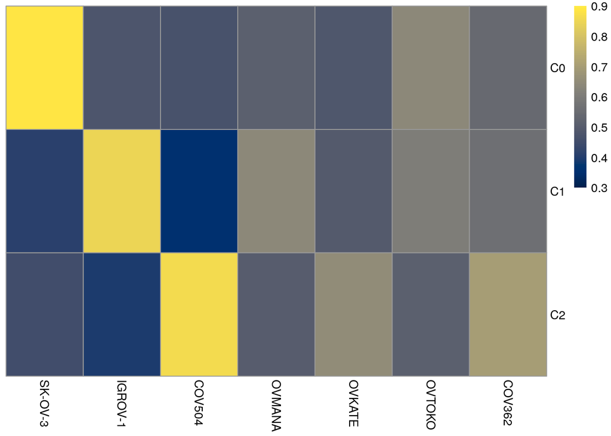

```r
pheatmap(
    cor_spearman,
    color = heatmap_palette(100, direction = heatmap_palette_direction),
    breaks = seq(min_cor_spearman, max_cor_spearman, length.out = 101),
    cluster_rows = FALSE, cluster_cols = FALSE
)
```

Mean relative difference matrix:

```r
as.data.frame(mean_rel_diff)
```

|  | SK-OV-3 | IGROV-1 | COV504 | OVMANA | OVKATE | OVTOKO | COV362 |
| --- | --- | --- | --- | --- | --- | --- | --- |
| C0 | 0.5502911 | 0.9881278 | 0.9052796 | 0.9143558 | 0.9274393 | 0.8363820 | 0.8962636 |
| C1 | 1.0502581 | 0.7123423 | 1.0538027 | 0.8267092 | 0.9888738 | 0.9008672 | 0.8912782 |
| C2 | 0.9608326 | 1.0549738 | 0.5702742 | 0.9489388 | 0.8232959 | 0.9519262 | 0.8294466 |

Mean relative difference heatmap:

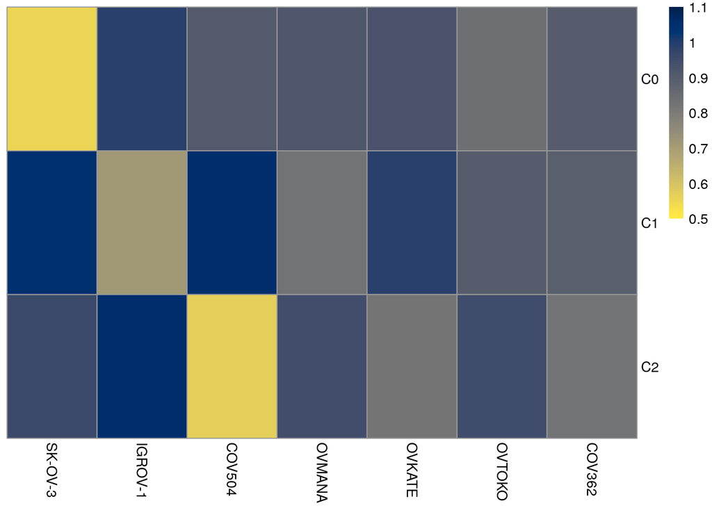

```r
pheatmap(
    mean_rel_diff,
    color = heatmap_palette(100, direction = -1),
    breaks = seq(min_mean_rel_diff, max_mean_rel_diff, length.out = 101),
    cluster_rows = FALSE, cluster_cols = FALSE
)
```

TPM scatter plots:

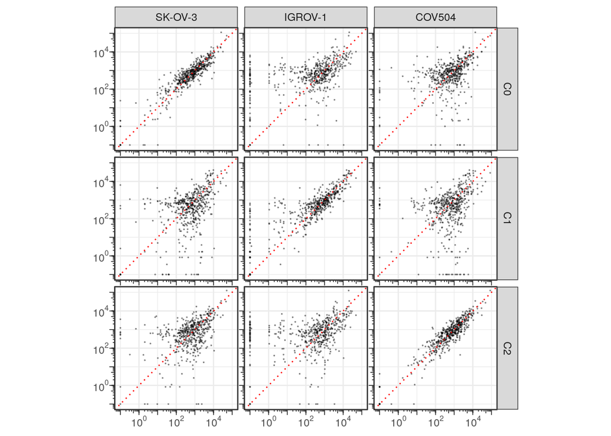

```r
scatterplot_df <- prepare_scatterplot_data(tpm_bulk,
                                           tpm_pseudobulk)
scatterplot_df$tool <- "Isosceles"
scatterplot_df_list[["Isosceles"]] <- scatterplot_df
create_scatterplot_paired(scatterplot_df)
```

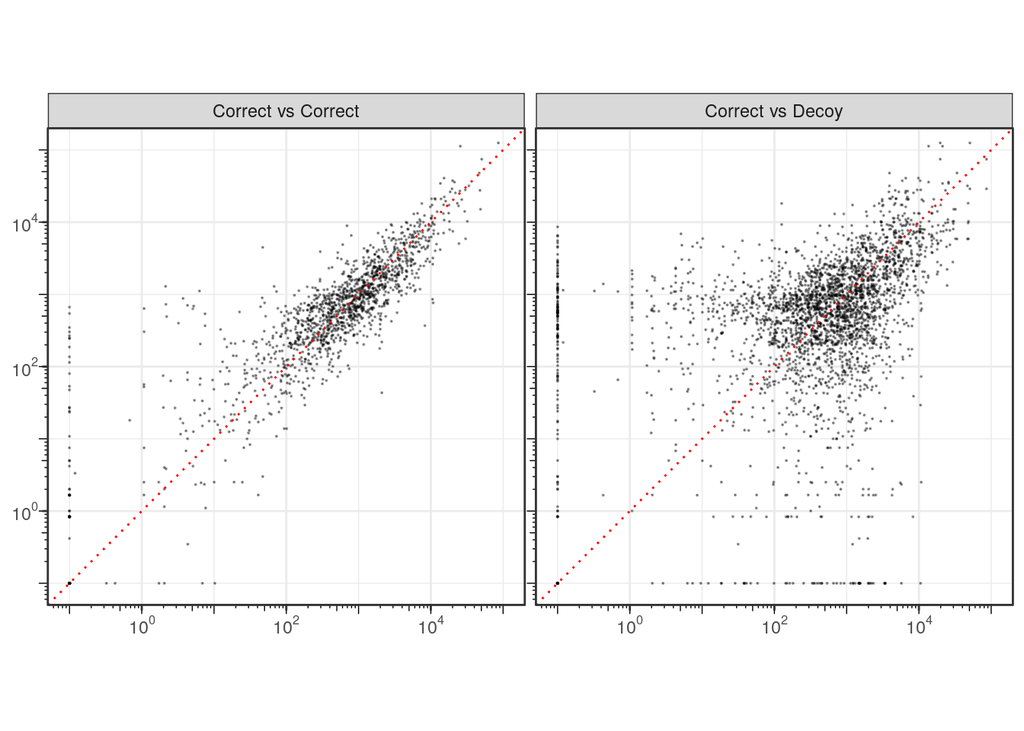

```r
create_scatterplot_combined(scatterplot_df)
```

# IsoQuant bulk-pseudobulk correlation plots

Prepare IsoQuant pseudobulk RNA-Seq data:

```r
isoquant_sc_df <- read_delim(file.path(
    sc_dir, "isoquant_transcript_grouped_tpm.tsv"
))
isoquant_sc_transcript_ids <- isoquant_sc_df[, 1, drop = TRUE]
isoquant_sc_counts <- as(as.matrix(isoquant_sc_df[, c(-1)]), "dgCMatrix")
rownames(isoquant_sc_counts) <- isoquant_sc_transcript_ids
isoquant_sc_counts <- isoquant_sc_counts[
    !(rownames(isoquant_sc_counts) %in% mt_transcripts_ensembl),
]
cell_labels <- souporcell_cluster[colnames(isoquant_sc_counts)]
cell_selector <- cell_labels %in% c("0", "1", "2")
isoquant_sc_counts <- isoquant_sc_counts[, cell_selector]
cell_labels <- cell_labels[cell_selector]
isoquant_pseudobulk_tpm <- t(rowsum(t(isoquant_sc_counts), cell_labels))
colnames(isoquant_pseudobulk_tpm) <- paste0(
    "C", colnames(isoquant_pseudobulk_tpm)
)
isoquant_pseudobulk_tpm <- t(
    t(isoquant_pseudobulk_tpm) / colSums(isoquant_pseudobulk_tpm) * 1e6
)
```

Prepare IsoQuant bulk RNA-Seq data:

```r
isoquant_bulk_list <- lapply(bulk_sample_ids, function(sample_id) {
    isoquant_df <- read_delim(file.path(
        bulk_dir, glue("isoquant_{sample_id}_transcript_tpm.tsv")
    ))
})
isoquant_bulk_tx_ids <- unique(unlist(sapply(
    isoquant_bulk_list, function(df) {df[, 1, drop = TRUE]}
)))
isoquant_bulk_tpm <- sapply(isoquant_bulk_list, function(df) {
    tpm_values <- df$TPM
    names(tpm_values) <- df[, 1, drop = TRUE]
    tpm_values <- tpm_values[isoquant_bulk_tx_ids]
    tpm_values[is.na(tpm_values)] <- 0
    return(tpm_values)
})
rownames(isoquant_bulk_tpm) <- isoquant_bulk_tx_ids
isoquant_bulk_tpm[, 7] <-
    (isoquant_bulk_tpm[, 7] + isoquant_bulk_tpm[, 8]) / 2
isoquant_bulk_tpm <- isoquant_bulk_tpm[, 1:7]
colnames(isoquant_bulk_tpm) <- bulk_sample_names
isoquant_bulk_tpm <- isoquant_bulk_tpm[, bulk_sample_order]
isoquant_bulk_tpm <- fill_missing_matrix(isoquant_bulk_tpm,
                                         rownames(isoquant_pseudobulk_tpm))
isoquant_bulk_tpm <- t(
    t(isoquant_bulk_tpm) / colSums(isoquant_bulk_tpm) * 1e6
)
```

Select top transcripts for further analysis:

```r
top_transcripts <- get_hvts(isoquant_sc_counts)
```

Re-normalize the TPM values:

```r
isoquant_bulk_tpm <- isoquant_bulk_tpm[top_transcripts,]
isoquant_pseudobulk_tpm <- isoquant_pseudobulk_tpm[top_transcripts,]
isoquant_bulk_tpm <- t(
    t(isoquant_bulk_tpm) / colSums(isoquant_bulk_tpm) * 1e6
)
isoquant_pseudobulk_tpm <- t(
    t(isoquant_pseudobulk_tpm) / colSums(isoquant_pseudobulk_tpm) * 1e6
)
```

Calculate the correlation matrices:

```r
cor_spearman <- cor(isoquant_pseudobulk_tpm[top_transcripts,],
                    isoquant_bulk_tpm[top_transcripts,],
                    method = "spearman")
mean_rel_diff <- get_mean_rel_diff_matrix(
    isoquant_pseudobulk_tpm[top_transcripts,],
    isoquant_bulk_tpm[top_transcripts,]
)
```

Spearman correlation matrix:

```r
as.data.frame(cor_spearman)
```

|  | SK-OV-3 | IGROV-1 | COV504 | OVMANA | OVKATE | OVTOKO | COV362 |
| --- | --- | --- | --- | --- | --- | --- | --- |
| C0 | 0.6528871 | 0.3564084 | 0.3314703 | 0.3712552 | 0.3699506 | 0.4796597 | 0.3886726 |
| C1 | 0.3706573 | 0.7268257 | 0.3098184 | 0.5467945 | 0.4121028 | 0.5327525 | 0.4837428 |
| C2 | 0.3481366 | 0.3263765 | 0.6846325 | 0.3663244 | 0.5284371 | 0.4084652 | 0.5376791 |

Spearman correlation heatmap:

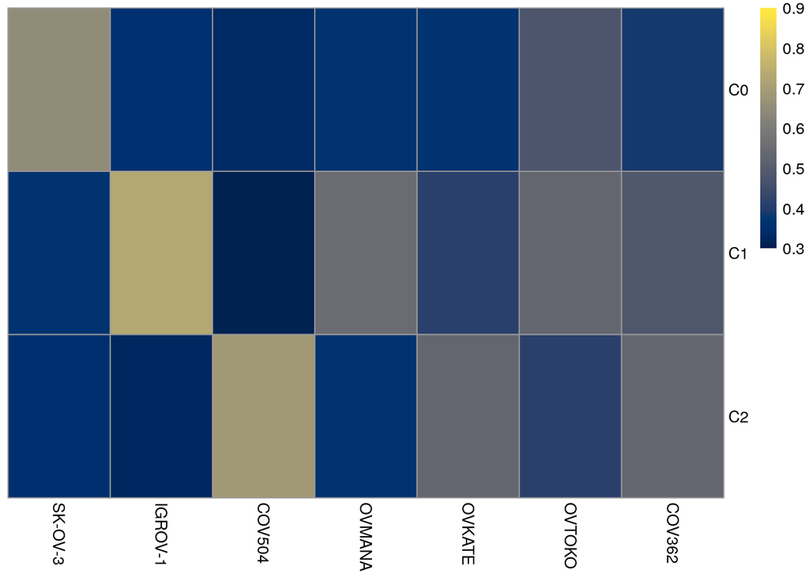

```r
pheatmap(
    cor_spearman,
    color = heatmap_palette(100, direction = heatmap_palette_direction),
    breaks = seq(min_cor_spearman, max_cor_spearman, length.out = 101),
    cluster_rows = FALSE, cluster_cols = FALSE
)
```

Mean relative difference matrix:

```r
as.data.frame(mean_rel_diff)
```

|  | SK-OV-3 | IGROV-1 | COV504 | OVMANA | OVKATE | OVTOKO | COV362 |
| --- | --- | --- | --- | --- | --- | --- | --- |
| C0 | 0.8022153 | 1.0352145 | 0.9906122 | 1.0248024 | 0.9858023 | 0.9658373 | 1.0253719 |
| C1 | 1.0462102 | 0.8453975 | 1.0407922 | 0.9448819 | 1.0082569 | 0.9659383 | 0.9824616 |
| C2 | 1.0233123 | 1.0495857 | 0.7815600 | 0.9976546 | 0.9229860 | 0.9882797 | 0.9455211 |

Mean relative difference heatmap:

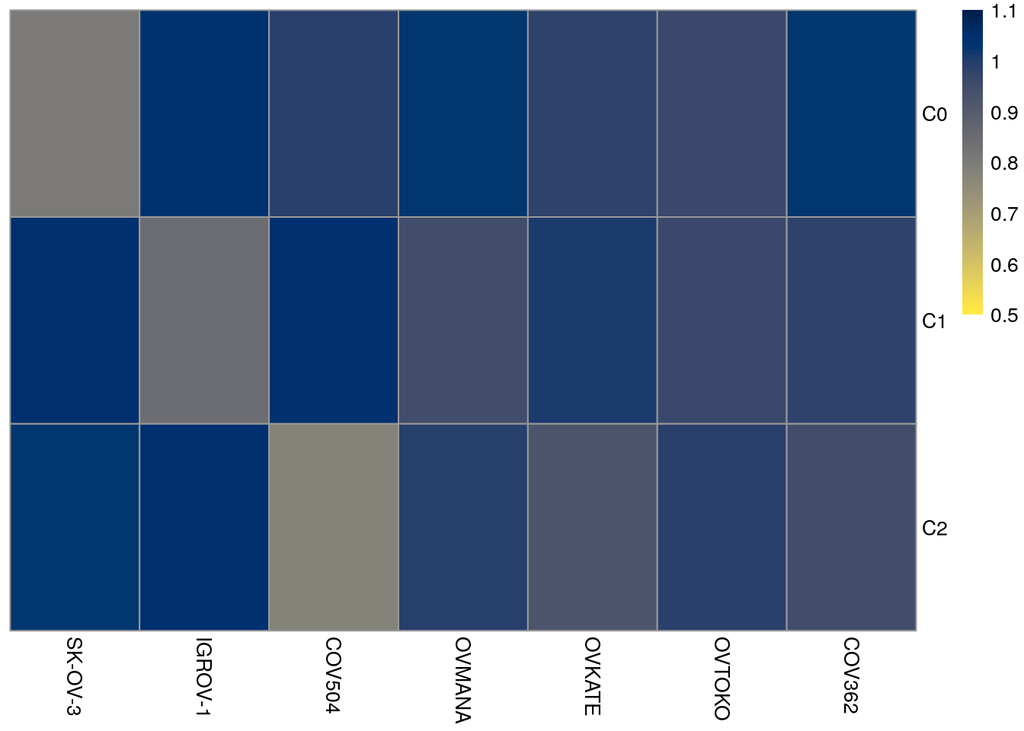

```r
pheatmap(
    mean_rel_diff,
    color = heatmap_palette(100, direction = -1),
    breaks = seq(min_mean_rel_diff, max_mean_rel_diff, length.out = 101),
    cluster_rows = FALSE, cluster_cols = FALSE
)
```

TPM scatter plots:

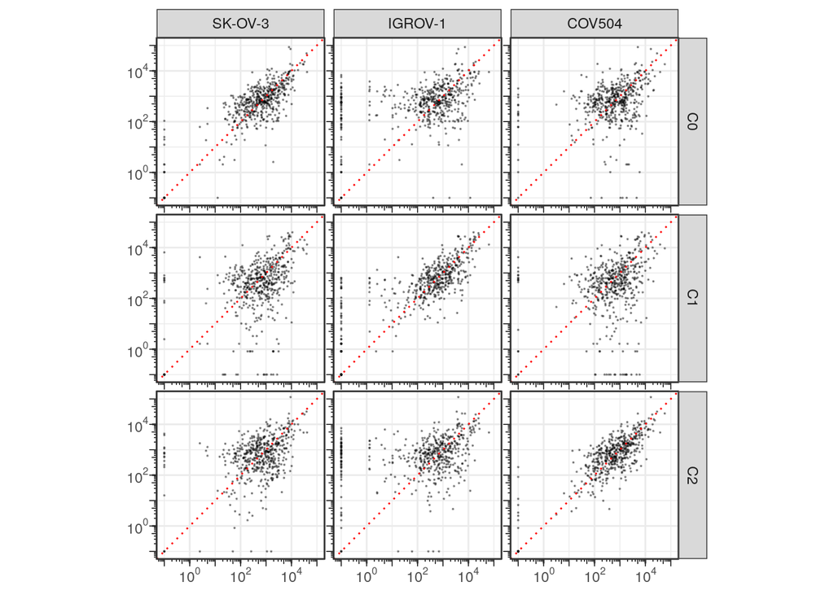

```r
scatterplot_df <- prepare_scatterplot_data(isoquant_bulk_tpm,
                                           isoquant_pseudobulk_tpm)
scatterplot_df$tool <- "IsoQuant"
scatterplot_df_list[["IsoQuant"]] <- scatterplot_df
create_scatterplot_paired(scatterplot_df)
```

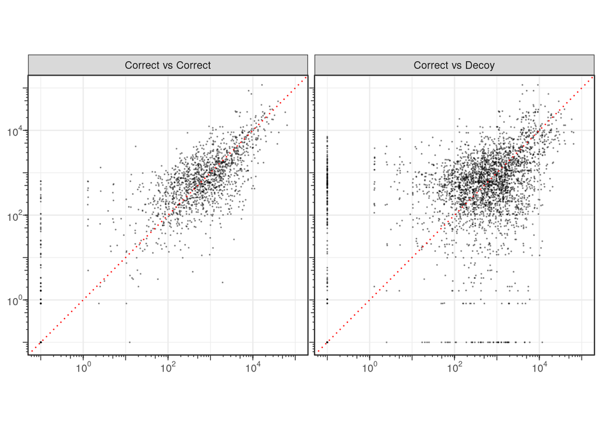

```r
create_scatterplot_combined(scatterplot_df)
```

# FLAMES bulk-pseudobulk correlation plots

Prepare FLAMES pseudobulk RNA-Seq data:

```r
flames_sc_df <- read_csv(file.path(
    sc_dir, "flames_transcript_count.csv.gz"
))
flames_sc_df <- flames_sc_df[!grepl("_", flames_sc_df$transcript_id),]
flames_sc_transcript_ids <- flames_sc_df$transcript_id
flames_sc_counts <- as(as.matrix(flames_sc_df[, c(-1, -2)]), "dgCMatrix")
rownames(flames_sc_counts) <- flames_sc_transcript_ids
flames_sc_counts <- flames_sc_counts[
    !(rownames(flames_sc_counts) %in% mt_transcripts_ensembl),
]
cell_labels <- souporcell_cluster[colnames(flames_sc_counts)]
cell_selector <- cell_labels %in% c("0", "1", "2")
flames_sc_counts <- flames_sc_counts[, cell_selector]
cell_labels <- cell_labels[cell_selector]
flames_pseudobulk_tpm <- t(rowsum(t(flames_sc_counts), cell_labels))
colnames(flames_pseudobulk_tpm) <- paste0(
    "C", colnames(flames_pseudobulk_tpm)
)
flames_pseudobulk_tpm <- t(
    t(flames_pseudobulk_tpm) / colSums(flames_pseudobulk_tpm) * 1e6
)
```

Prepare FLAMES bulk RNA-Seq data:

```r
flames_bulk_list <- lapply(bulk_sample_ids, function(sample_id) {
    flames_df <- read_csv(file.path(
        bulk_dir, glue("flames_{sample_id}_transcript_count.csv.gz")
    ))
    flames_df <- flames_df[!grepl("_", flames_df$transcript_id),]
    return(flames_df)
})
flames_bulk_tx_ids <- unique(unlist(sapply(
    flames_bulk_list, function(df) {df$transcript_id}
)))
flames_bulk_tpm <- sapply(flames_bulk_list, function(df) {
    tpm_values <- df[, 3, drop = TRUE]
    names(tpm_values) <- df$transcript_id
    tpm_values <- tpm_values[flames_bulk_tx_ids]
    tpm_values[is.na(tpm_values)] <- 0
    return(tpm_values)
})
rownames(flames_bulk_tpm) <- flames_bulk_tx_ids
flames_bulk_tpm <- t(t(flames_bulk_tpm) / colSums(flames_bulk_tpm) * 1e6)
flames_bulk_tpm[, 7] <- (flames_bulk_tpm[, 7] + flames_bulk_tpm[, 8]) / 2
flames_bulk_tpm <- flames_bulk_tpm[, 1:7]
colnames(flames_bulk_tpm) <- bulk_sample_names
flames_bulk_tpm <- flames_bulk_tpm[, bulk_sample_order]
flames_bulk_tpm <- fill_missing_matrix(flames_bulk_tpm,
                                       rownames(flames_pseudobulk_tpm))
flames_bulk_tpm <- t(
    t(flames_bulk_tpm) / colSums(flames_bulk_tpm) * 1e6
)
```

Select top transcripts for further analysis:

```r
top_transcripts <- get_hvts(flames_sc_counts)
```

Re-normalize the TPM values:

```r
flames_bulk_tpm <- flames_bulk_tpm[top_transcripts,]
flames_pseudobulk_tpm <- flames_pseudobulk_tpm[top_transcripts,]
flames_bulk_tpm <- t(
    t(flames_bulk_tpm) / colSums(flames_bulk_tpm) * 1e6
)
flames_pseudobulk_tpm <- t(
    t(flames_pseudobulk_tpm) / colSums(flames_pseudobulk_tpm) * 1e6
)
```

Calculate the correlation matrices:

```r
cor_spearman <- cor(flames_pseudobulk_tpm[top_transcripts,],
                    flames_bulk_tpm[top_transcripts,],
                    method = "spearman")
mean_rel_diff <- get_mean_rel_diff_matrix(
    flames_pseudobulk_tpm[top_transcripts,],
    flames_bulk_tpm[top_transcripts,]
)
```

Spearman correlation matrix:

```r
as.data.frame(cor_spearman)
```

|  | SK-OV-3 | IGROV-1 | COV504 | OVMANA | OVKATE | OVTOKO | COV362 |
| --- | --- | --- | --- | --- | --- | --- | --- |
| C0 | 0.6606337 | 0.5572473 | 0.5029991 | 0.5055960 | 0.4965469 | 0.5639037 | 0.5605361 |
| C1 | 0.4951039 | 0.7164009 | 0.5372125 | 0.6484456 | 0.5576051 | 0.6031317 | 0.6107870 |
| C2 | 0.3957966 | 0.4905890 | 0.7038009 | 0.4783894 | 0.5393477 | 0.5117073 | 0.6294376 |

Spearman correlation heatmap:

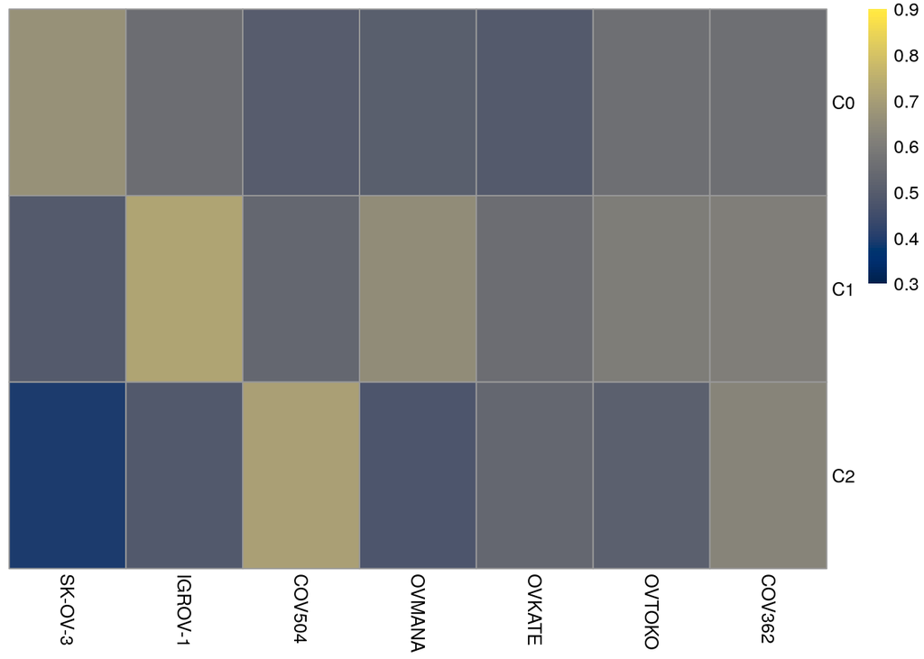

```r
pheatmap(
    cor_spearman,
    color = heatmap_palette(100, direction = heatmap_palette_direction),
    breaks = seq(min_cor_spearman, max_cor_spearman, length.out = 101),
    cluster_rows = FALSE, cluster_cols = FALSE
)
```

Mean relative difference matrix:

```r
as.data.frame(mean_rel_diff)
```

|  | SK-OV-3 | IGROV-1 | COV504 | OVMANA | OVKATE | OVTOKO | COV362 |
| --- | --- | --- | --- | --- | --- | --- | --- |
| C0 | 0.5474599 | 0.8178831 | 0.8517947 | 0.8113056 | 0.8448419 | 0.7430332 | 0.7915908 |
| C1 | 0.9642916 | 0.6300451 | 0.9847105 | 0.8509392 | 1.0065032 | 0.8100193 | 0.8688320 |
| C2 | 0.8798920 | 0.8888357 | 0.5882667 | 0.8522851 | 0.7745588 | 0.8393100 | 0.7069380 |

Mean relative difference heatmap:

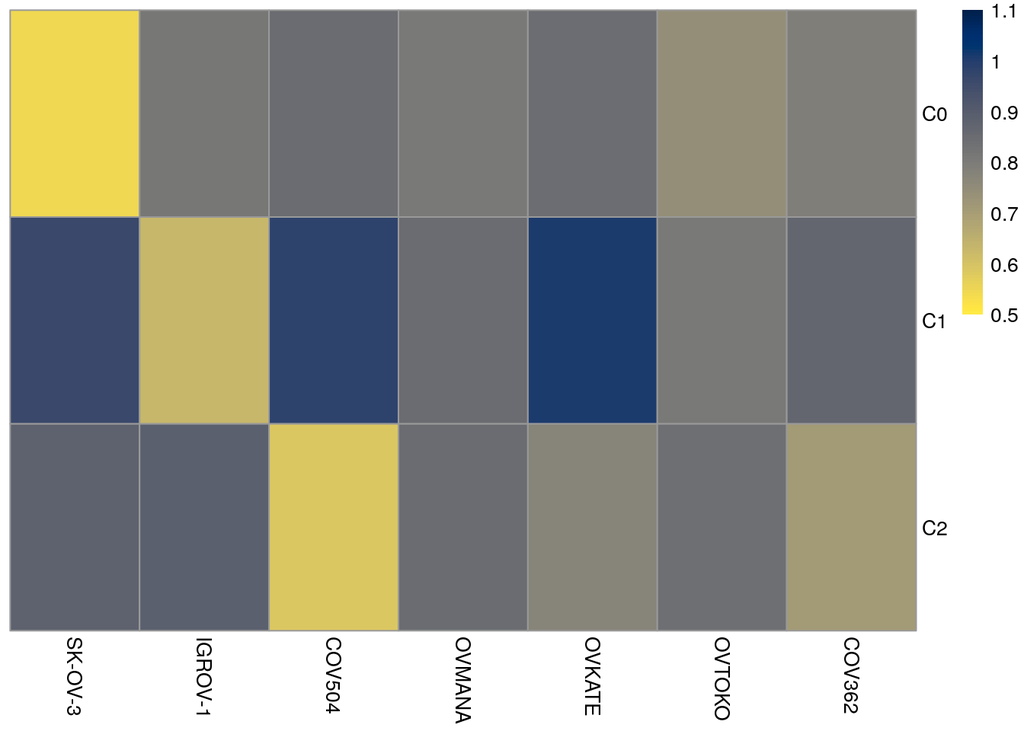

```r
pheatmap(
    mean_rel_diff,
    color = heatmap_palette(100, direction = -1),
    breaks = seq(min_mean_rel_diff, max_mean_rel_diff, length.out = 101),
    cluster_rows = FALSE, cluster_cols = FALSE
)
```

TPM scatter plots:

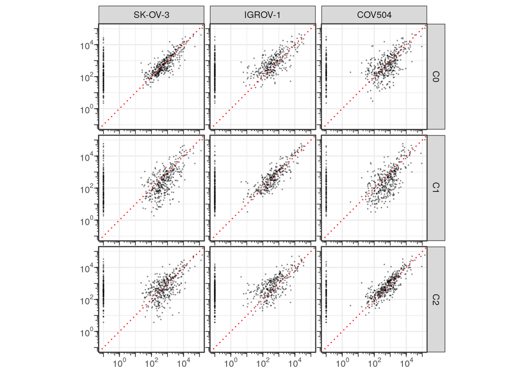

```r
scatterplot_df <- prepare_scatterplot_data(flames_bulk_tpm,
                                           flames_pseudobulk_tpm)
scatterplot_df$tool <- "FLAMES"
scatterplot_df_list[["FLAMES"]] <- scatterplot_df
create_scatterplot_paired(scatterplot_df)
```

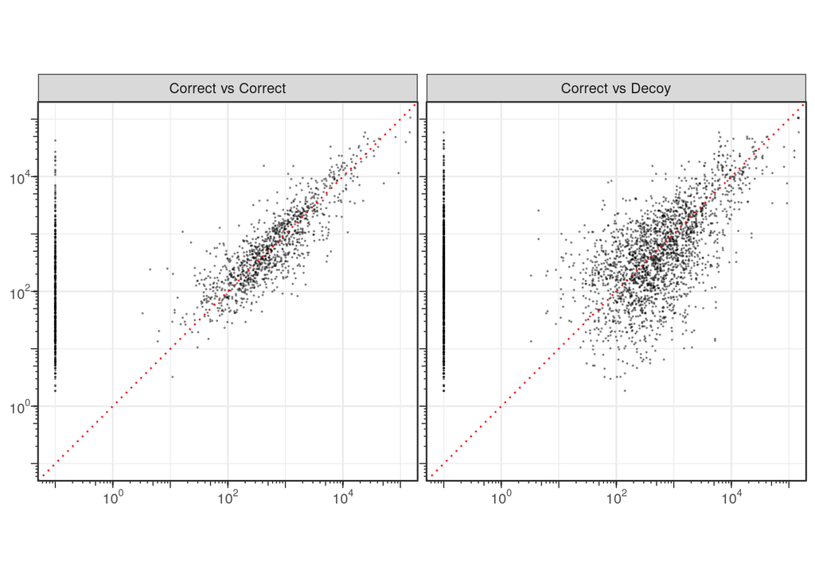

```r
create_scatterplot_combined(scatterplot_df)
```

# Sicelore bulk-pseudobulk correlation plots

Prepare Sicelore pseudobulk RNA-Seq data:

```r
sicelore_sc_df <- read_delim(file.path(
    sc_dir, "sicelore_isomatrix.txt"
))
sicelore_sc_df <- sicelore_sc_df[sicelore_sc_df$transcriptId != "undef",]
sicelore_sc_transcript_ids <- sicelore_sc_df$transcriptId
sicelore_sc_counts <- as(as.matrix(sicelore_sc_df[, c(-1, -2, -3)]),
                         "dgCMatrix")
rownames(sicelore_sc_counts) <- sicelore_sc_transcript_ids
sicelore_sc_counts <- sicelore_sc_counts[
    !(rownames(sicelore_sc_counts) %in% mt_transcripts_ensembl),
]
cell_labels <- souporcell_cluster[colnames(sicelore_sc_counts)]
cell_selector <- cell_labels %in% c("0", "1", "2")
sicelore_sc_counts <- sicelore_sc_counts[, cell_selector]
cell_labels <- cell_labels[cell_selector]
sicelore_pseudobulk_tpm <- t(rowsum(t(sicelore_sc_counts), cell_labels))
colnames(sicelore_pseudobulk_tpm) <- paste0(
    "C", colnames(sicelore_pseudobulk_tpm)
)
sicelore_pseudobulk_tpm <- t(
    t(sicelore_pseudobulk_tpm) / colSums(sicelore_pseudobulk_tpm) * 1e6
)
```

Prepare Sicelore bulk RNA-Seq data:

```r
sicelore_bulk_list <- lapply(bulk_sample_ids, function(sample_id) {
    sicelore_df <- read_delim(file.path(
        bulk_dir, glue("sicelore_{sample_id}_sicelore_isomatrix.txt")
    ))
    sicelore_df <- sicelore_df[sicelore_df$transcriptId != "undef",]
    return(sicelore_df)
})
sicelore_bulk_tx_ids <- unique(unlist(sapply(
    sicelore_bulk_list, function(df) {df$transcriptId}
)))
sicelore_bulk_tpm <- sapply(sicelore_bulk_list, function(df) {
    tpm_values <- df[, 4, drop = TRUE]
    names(tpm_values) <- df$transcriptId
    tpm_values <- tpm_values[sicelore_bulk_tx_ids]
    tpm_values[is.na(tpm_values)] <- 0
    return(tpm_values)
})
rownames(sicelore_bulk_tpm) <- sicelore_bulk_tx_ids
sicelore_bulk_tpm <- t(
    t(sicelore_bulk_tpm) / colSums(sicelore_bulk_tpm) * 1e6
)
sicelore_bulk_tpm[, 7] <-
    (sicelore_bulk_tpm[, 7] + sicelore_bulk_tpm[, 8]) / 2
sicelore_bulk_tpm <- sicelore_bulk_tpm[, 1:7]
colnames(sicelore_bulk_tpm) <- bulk_sample_names
sicelore_bulk_tpm <- sicelore_bulk_tpm[, bulk_sample_order]
sicelore_bulk_tpm <- fill_missing_matrix(sicelore_bulk_tpm,
                                         rownames(sicelore_pseudobulk_tpm))
sicelore_bulk_tpm <- t(
    t(sicelore_bulk_tpm) / colSums(sicelore_bulk_tpm) * 1e6
)
```

Select top transcripts for further analysis:

```r
top_transcripts <- get_hvts(sicelore_sc_counts)
```

Re-normalize the TPM values:

```r
sicelore_bulk_tpm <- sicelore_bulk_tpm[top_transcripts,]
sicelore_pseudobulk_tpm <- sicelore_pseudobulk_tpm[top_transcripts,]
sicelore_bulk_tpm <- t(
    t(sicelore_bulk_tpm) / colSums(sicelore_bulk_tpm) * 1e6
)
sicelore_pseudobulk_tpm <- t(
    t(sicelore_pseudobulk_tpm) / colSums(sicelore_pseudobulk_tpm) * 1e6
)
```

Calculate the correlation matrices:

```r
cor_spearman <- cor(sicelore_pseudobulk_tpm[top_transcripts,],
                    sicelore_bulk_tpm[top_transcripts,],
                    method = "spearman")
mean_rel_diff <- get_mean_rel_diff_matrix(
    sicelore_pseudobulk_tpm[top_transcripts,],
    sicelore_bulk_tpm[top_transcripts,]
)
```

Spearman correlation matrix:

```r
as.data.frame(cor_spearman)
```

|  | SK-OV-3 | IGROV-1 | COV504 | OVMANA | OVKATE | OVTOKO | COV362 |
| --- | --- | --- | --- | --- | --- | --- | --- |
| C0 | 0.8465456 | 0.5480250 | 0.5259399 | 0.5995570 | 0.5392340 | 0.6753985 | 0.6062355 |
| C1 | 0.5291341 | 0.8524080 | 0.5042714 | 0.7224789 | 0.5727572 | 0.6706368 | 0.6234157 |
| C2 | 0.4914252 | 0.5002808 | 0.8455551 | 0.5680085 | 0.6722836 | 0.5434152 | 0.7402439 |

Spearman correlation heatmap:

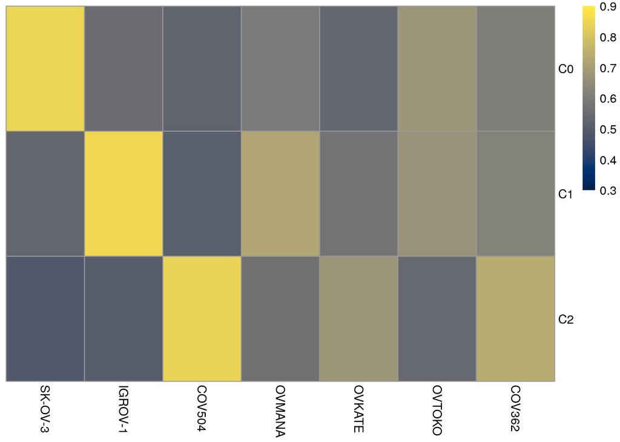

```r
pheatmap(
    cor_spearman,
    color = heatmap_palette(100, direction = heatmap_palette_direction),
    breaks = seq(min_cor_spearman, max_cor_spearman, length.out = 101),
    cluster_rows = FALSE, cluster_cols = FALSE
)
```

Mean relative difference matrix:

```r
as.data.frame(mean_rel_diff)
```

|  | SK-OV-3 | IGROV-1 | COV504 | OVMANA | OVKATE | OVTOKO | COV362 |
| --- | --- | --- | --- | --- | --- | --- | --- |
| C0 | 0.5847871 | 0.9478640 | 0.8975143 | 0.8839512 | 0.9105959 | 0.8346449 | 0.8634362 |
| C1 | 0.9739649 | 0.6623514 | 0.9806667 | 0.7851145 | 0.9467668 | 0.8096520 | 0.8547433 |
| C2 | 0.9277182 | 0.9313826 | 0.6405887 | 0.8928530 | 0.8184014 | 0.9031964 | 0.8051535 |

Mean relative difference heatmap:

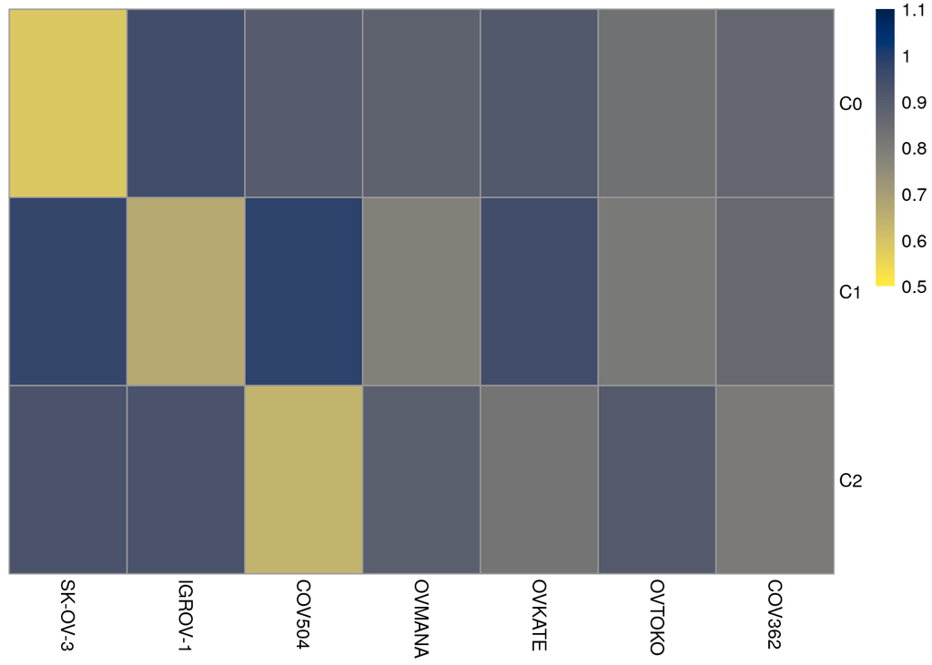

```r
pheatmap(
    mean_rel_diff,
    color = heatmap_palette(100, direction = -1),
    breaks = seq(min_mean_rel_diff, max_mean_rel_diff, length.out = 101),
    cluster_rows = FALSE, cluster_cols = FALSE
)
```

TPM scatter plots:

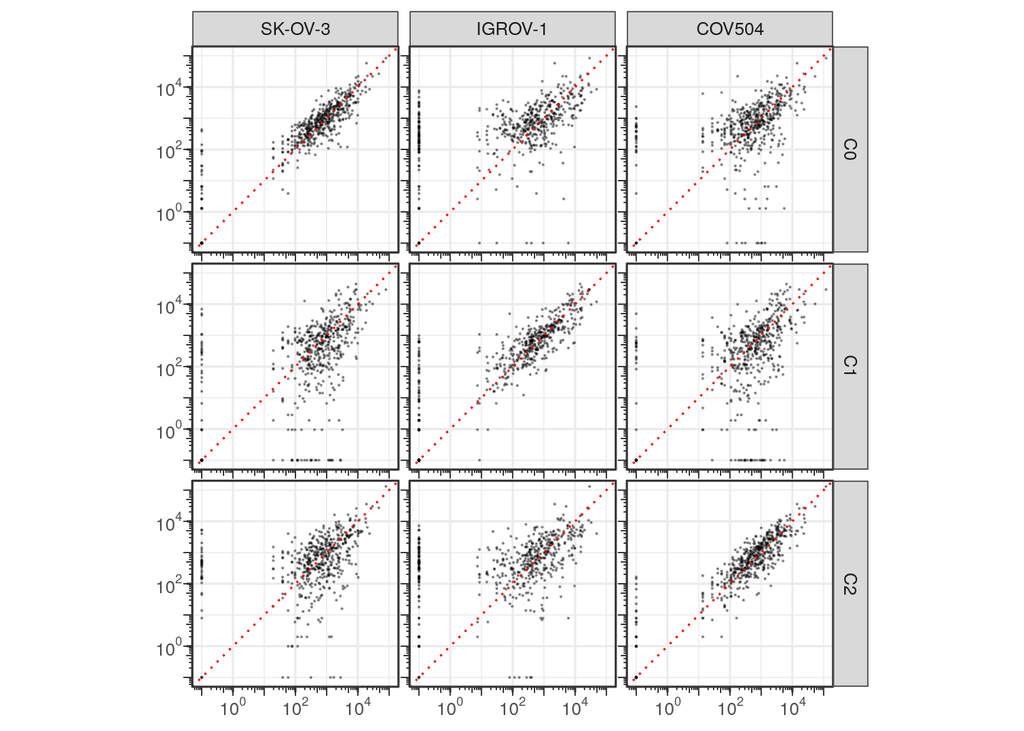

```r
scatterplot_df <- prepare_scatterplot_data(sicelore_bulk_tpm,
                                           sicelore_pseudobulk_tpm)
scatterplot_df$tool <- "Sicelore"
scatterplot_df_list[["Sicelore"]] <- scatterplot_df
create_scatterplot_paired(scatterplot_df)
```

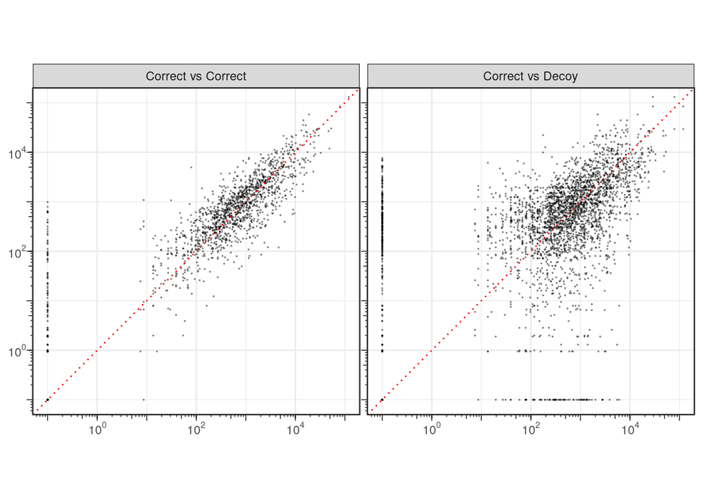

```r
create_scatterplot_combined(scatterplot_df)
```

# Summary barplots

Prepare summary barplot data:

```r
plot_df <- do.call(rbind, scatterplot_df_list)
rownames(plot_df) <- NULL
plot_df$tool <- factor(plot_df$tool, levels = c("Isosceles", "IsoQuant",
                                                "FLAMES", "Sicelore"))
plot_df <- plot_df %>%
    group_by(tool, sample_bulk, sample_pseudobulk) %>%
    summarise(
        status = unique(status),
        corr_spearman = cor(tpm_bulk, tpm_pseudobulk,
                            method = "spearman"),
        mean_rel_diff = get_mean_rel_diff(tpm_bulk, tpm_pseudobulk)
    ) %>%
    ungroup()
test_values_df <- plot_df %>%
    group_by(tool, sample_pseudobulk, status) %>%
    summarise(
        corr_spearman = mean(corr_spearman),
        mean_rel_diff = mean(mean_rel_diff)
    ) %>%
    ungroup() %>%
    mutate(
        status = gsub("Correct vs ", "", status)
    ) %>%
    pivot_wider(id_cols = c(tool, sample_pseudobulk),
                names_from = status,
                values_from = c(corr_spearman, mean_rel_diff)) %>%
    transmute(
        tool = tool,
        sample_pseudobulk = sample_pseudobulk,
        corr_spearman = abs(corr_spearman_Correct - corr_spearman_Decoy),
        mean_rel_diff = abs(mean_rel_diff_Correct - mean_rel_diff_Decoy)
    )
plot_df <- plot_df %>%
    group_by(tool, status) %>%
    summarise(
        corr_spearman_avg = mean(corr_spearman),
        corr_spearman_se = sd(corr_spearman) / sqrt(n()),
        mean_rel_diff_avg = mean(mean_rel_diff),
        mean_rel_diff_se = sd(mean_rel_diff) / sqrt(n())
    ) %>%
    ungroup()
```

Summary barplot (Spearman correlation):

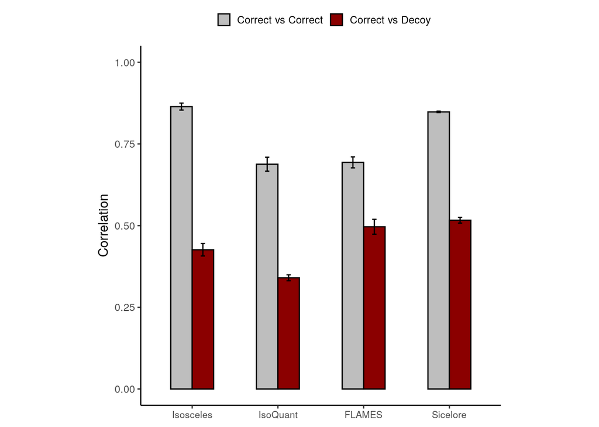

```r
ggplot(plot_df, mapping = aes(x = tool,
                              y = corr_spearman_avg,
                              fill = status)) +
    geom_col(position = position_dodge(), color = "black", width = 0.5) +
    geom_errorbar(
        mapping = aes(ymin = corr_spearman_avg - corr_spearman_se,
                      ymax = corr_spearman_avg + corr_spearman_se),
        width = 0.1,
        color = "black",
        position = position_dodge(0.5)
    ) +
    scale_fill_manual(values = c(`Correct vs Correct` = "grey",
                                 `Correct vs Decoy` = "darkred")) +
    coord_cartesian(ylim = c(0, 1)) +
    labs(y = "Correlation",
         fill = "") +
    theme_classic() +
    theme(legend.position = "top",
          legend.key.size = unit(0.4, "cm"),
          aspect.ratio = 1,
          axis.title.x = element_blank(),
          axis.text.x = element_text(size = 8))
```

Summary barplot (mean relative difference):

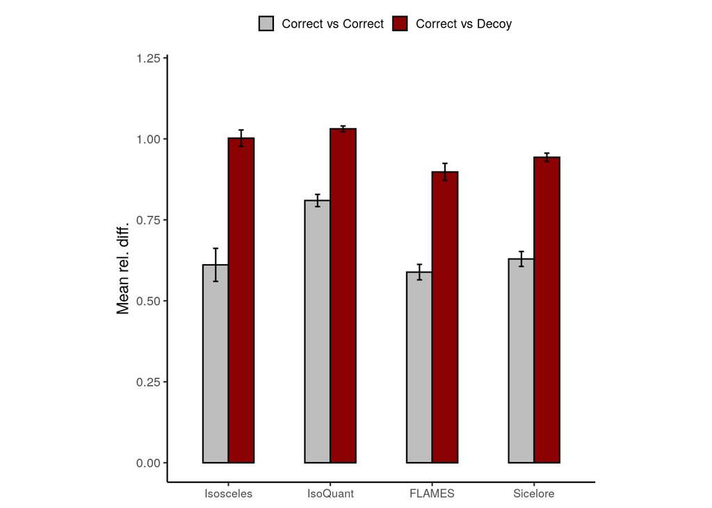

```r
ggplot(plot_df, mapping = aes(x = tool,
                              y = mean_rel_diff_avg,
                              fill = status)) +
    geom_col(position = position_dodge(), color = "black", width = 0.5) +
    geom_errorbar(
        mapping = aes(ymin = mean_rel_diff_avg - mean_rel_diff_se,
                      ymax = mean_rel_diff_avg + mean_rel_diff_se),
        width = 0.1,
        color = "black",
        position = position_dodge(0.5)
    ) +
    scale_fill_manual(values = c(`Correct vs Correct` = "grey",
                                 `Correct vs Decoy` = "darkred")) +
    coord_cartesian(ylim = c(0, max_mean_rel_diff + 0.1)) +
    labs(y = "Mean rel. diff.",
         fill = "") +
    theme_classic() +
    theme(legend.position = "top",
          legend.key.size = unit(0.4, "cm"),
          aspect.ratio = 1,
          axis.title.x = element_blank(),
          axis.text.x = element_text(size = 8))
```

Metric difference and CI table:

```r
get_diff_value <- function(x) {
    return(abs(x[1] - x[2]))
}
get_diff_sd <- function(x) {
    return(sqrt(sum(x ** 2)))
}
get_ci_factor <- function(x) {
    qnorm(1 - (1 - x)/2)
}
diff_df <- plot_df %>%
    group_by(tool) %>%
    summarise(
        corr_spearman = get_diff_value(corr_spearman_avg),
        corr_spearman_upper_ci_95 = get_diff_value(corr_spearman_avg) +
            (get_diff_sd(corr_spearman_se) * get_ci_factor(0.95)),
        corr_spearman_lower_ci_95 = get_diff_value(corr_spearman_avg) -
            (get_diff_sd(corr_spearman_se) * get_ci_factor(0.95)),
        corr_spearman_upper_ci_90 = get_diff_value(corr_spearman_avg) +
            (get_diff_sd(corr_spearman_se) * get_ci_factor(0.90)),
        corr_spearman_lower_ci_90 = get_diff_value(corr_spearman_avg) -
            (get_diff_sd(corr_spearman_se) * get_ci_factor(0.90)),
        corr_spearman_upper_ci_68 = get_diff_value(corr_spearman_avg) +
            (get_diff_sd(corr_spearman_se) * get_ci_factor(0.68)),
        corr_spearman_lower_ci_68 = get_diff_value(corr_spearman_avg) -
            (get_diff_sd(corr_spearman_se) * get_ci_factor(0.68)),
        mean_rel_diff = get_diff_value(mean_rel_diff_avg),
        mean_rel_diff_upper_ci_95 = get_diff_value(mean_rel_diff_avg) +
            (get_diff_sd(mean_rel_diff_se) * get_ci_factor(0.95)),
        mean_rel_diff_lower_ci_95 = get_diff_value(mean_rel_diff_avg) -
            (get_diff_sd(mean_rel_diff_se) * get_ci_factor(0.95)),
        mean_rel_diff_upper_ci_90 = get_diff_value(mean_rel_diff_avg) +
            (get_diff_sd(mean_rel_diff_se) * get_ci_factor(0.90)),
        mean_rel_diff_lower_ci_90 = get_diff_value(mean_rel_diff_avg) -
            (get_diff_sd(mean_rel_diff_se) * get_ci_factor(0.90)),
        mean_rel_diff_upper_ci_68 = get_diff_value(mean_rel_diff_avg) +
            (get_diff_sd(mean_rel_diff_se) * get_ci_factor(0.68)),
        mean_rel_diff_lower_ci_68 = get_diff_value(mean_rel_diff_avg) -
            (get_diff_sd(mean_rel_diff_se) * get_ci_factor(0.68))
    )
diff_df <- as.data.frame(diff_df)
rownames(diff_df) <- diff_df$tool
diff_df$tool <- NULL
diff_df <- as.data.frame(t(diff_df))
write.csv(diff_df, file.path(csv_dir, glue("data_{top_n_hvts}_hvts.csv")))
write.csv(
    test_values_df,
    file.path(csv_dir,glue("test_values_{top_n_hvts}_hvts.csv")),
    row.names = FALSE
)
diff_df
```

|  | Isosceles | IsoQuant | FLAMES | Sicelore |
| --- | --- | --- | --- | --- |
| corr_spearman | 0.4381894 | 0.3476372 | 0.1971204 | 0.3316568 |
| corr_spearman_upper_ci_95 | 0.4809064 | 0.3931848 | 0.2526969 | 0.3492641 |
| corr_spearman_lower_ci_95 | 0.3954724 | 0.3020897 | 0.1415440 | 0.3140495 |
| corr_spearman_upper_ci_90 | 0.4740386 | 0.3858619 | 0.2437616 | 0.3464333 |
| corr_spearman_lower_ci_90 | 0.4023401 | 0.3094125 | 0.1504792 | 0.3168803 |
| corr_spearman_upper_ci_68 | 0.4598634 | 0.3707474 | 0.2253191 | 0.3405905 |
| corr_spearman_lower_ci_68 | 0.4165154 | 0.3245270 | 0.1689217 | 0.3227231 |
| mean_rel_diff | 0.3912432 | 0.2212302 | 0.3093107 | 0.3139427 |
| mean_rel_diff_upper_ci_95 | 0.5027675 | 0.2620170 | 0.3790023 | 0.3656063 |
| mean_rel_diff_lower_ci_95 | 0.2797189 | 0.1804434 | 0.2396190 | 0.2622792 |

[output cut: 4 more lines]